# Prostate cancer analysis

2022-05-10

## Article introduction

**Title:** “Peripheral Blood Mitochondrial DNA Copy Number Is Associated with Prostate Cancer Risk and Tumor Burden”

**Authors:** Weimin Zhou, Min Zhu, Ming Gui, Lihua Huang, Zhi Long, Li Wang, Hui Chen, Yinghao Yin, Xianzhen Jiang, Yingbo Dai, Yuxin Tang, Leye He, Kuangbiao Zhong

**Goal:** Determine if mtDNA is a predictor for prostate cancer

## Data set overview

**Loading**

- Dimensions of the raw data set: 392, 13
- Stratified on Controls and prostate cancer cases (attribute called Group)
- Purpose of article: Predict prostate cancer from other variables, mainly mtDNA

**Cleaning**

- Check for duplicates
- Filter for PCRsuccess
- New dimensions: 387, 13

**Augmenting**

- BMI- and DFI-classifier
- New columns based on TNM-notation
- Add “Group” as strings
- New dimensions: 387, 18

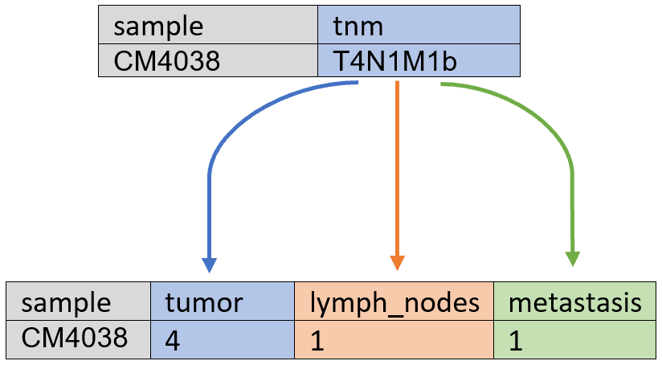

## Boxplot with continuous variables, any outliers?

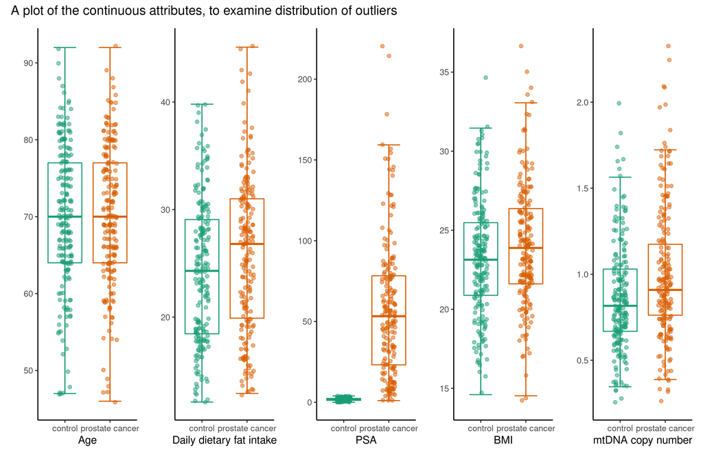

## Boxplot with discrete variables, any outliers?

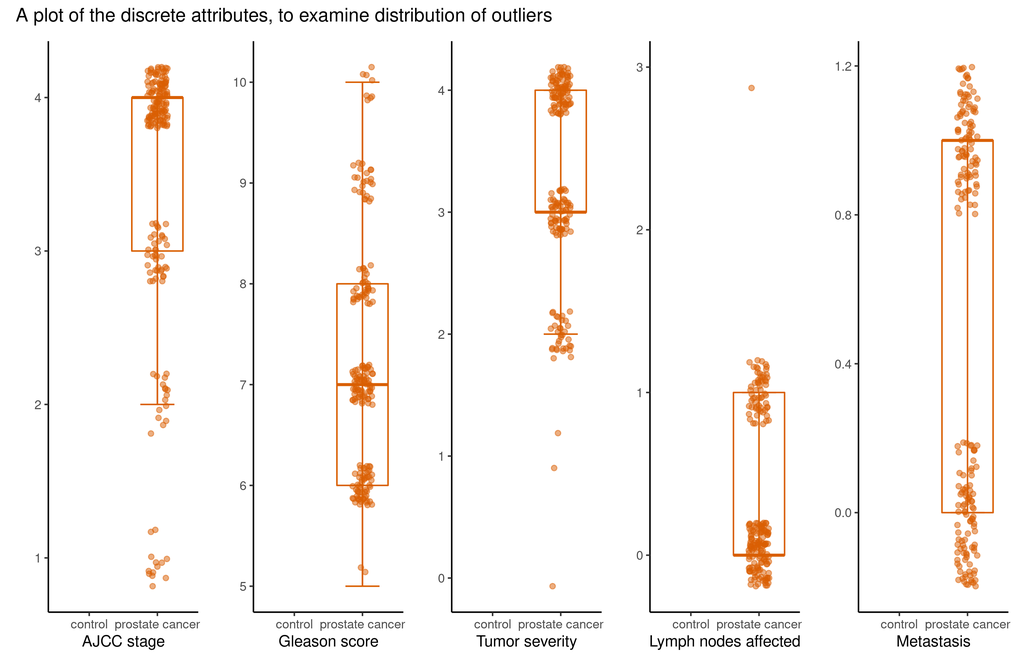

## Re-creating plot from the article

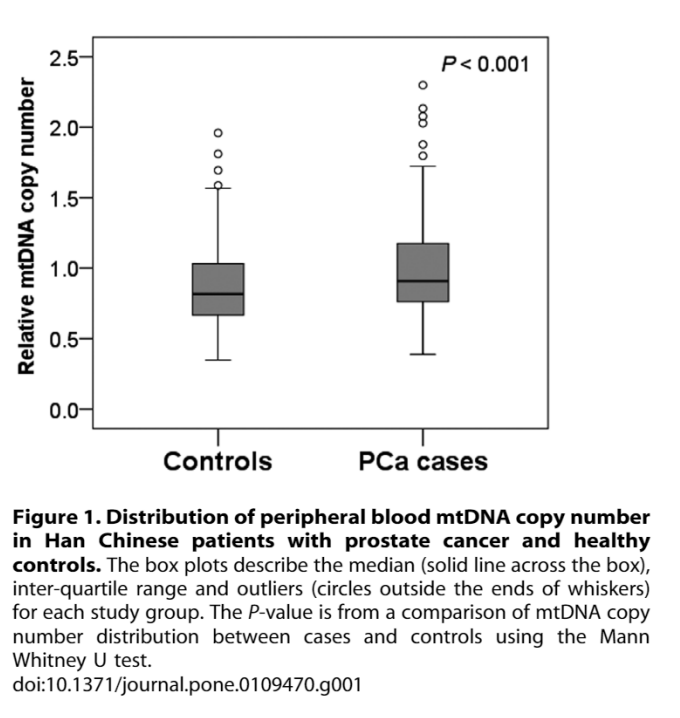

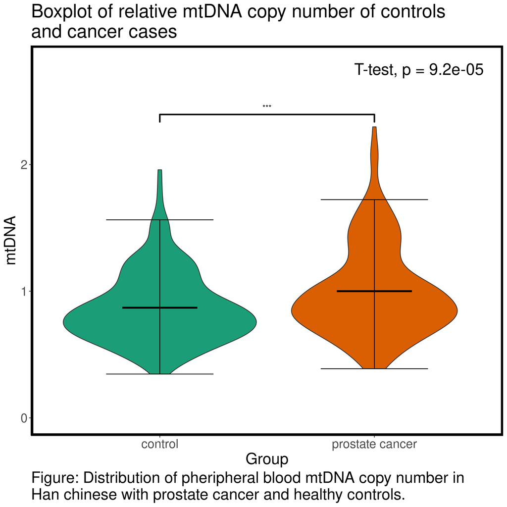

Article visualization

## A better biomarker for prostate cancer?

[figure not shown]

## Logistic regression, excl. PSA

Significant p-values:

| dfi_class | term | estimate | p.value | identified_as |
| --- | --- | --- | --- | --- |
| low fat | mtdna | 1.392 | 0.041 | Significant |
| medium fat | mtdna | 1.473 | 0.005 | Significant |

Maybe the distribution of DFI-classes are skewed?

| dfi_class | group | n |
| --- | --- | --- |
| high fat | 0 | 41 |
| high fat | 1 | 60 |
| low fat | 0 | 67 |
| low fat | 1 | 49 |
| medium fat | 0 | 86 |
| medium fat | 1 | 84 |

## Logistic regression, incl. PSA

Significant p-values:

| dfi_class | term | estimate | p.value | identified_as |
| --- | --- | --- | --- | --- |
| medium fat | psa | 1.631 | 0.004 | Significant |
| high fat | psa | 2.033 | 0.018 | Significant |

## Principal component analysis (PCA)

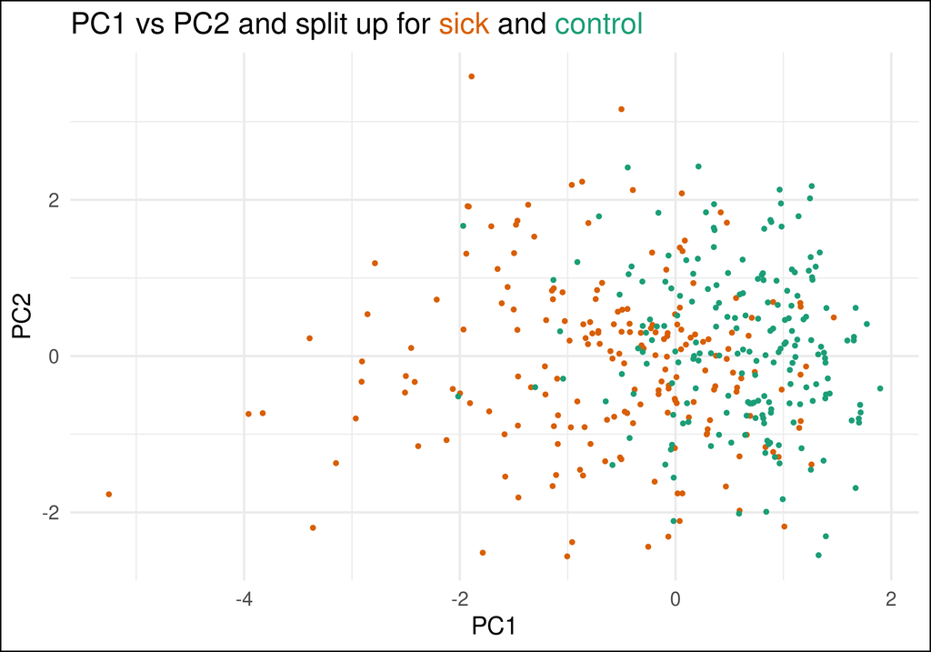

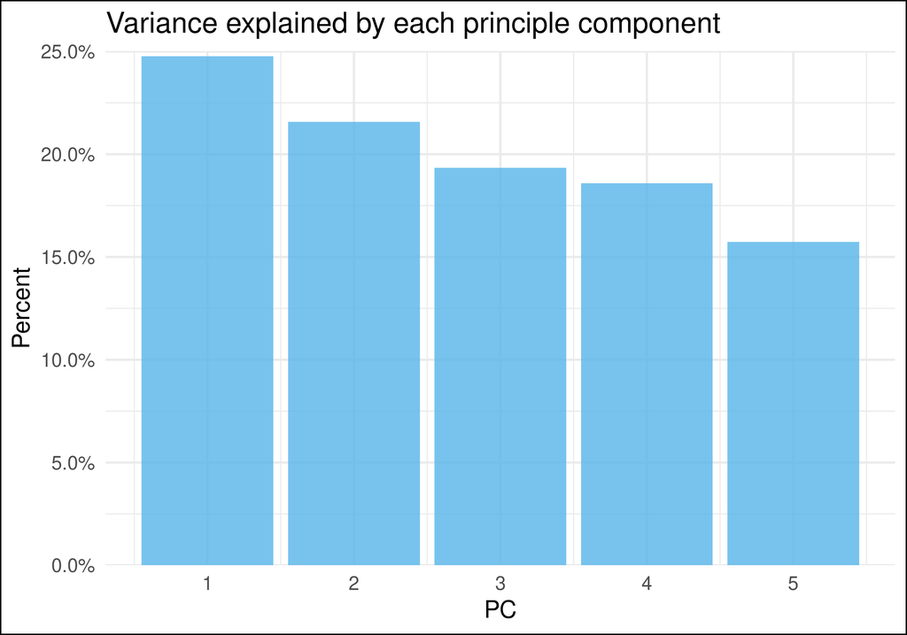

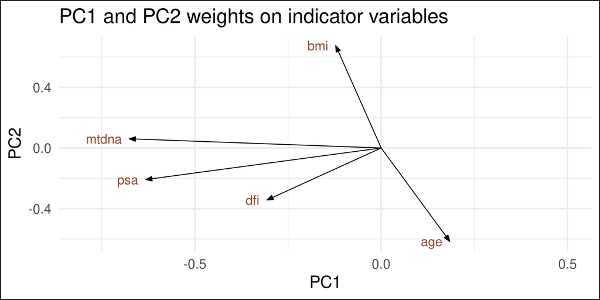

PCA

## Interesting finding during exploratory data analysis

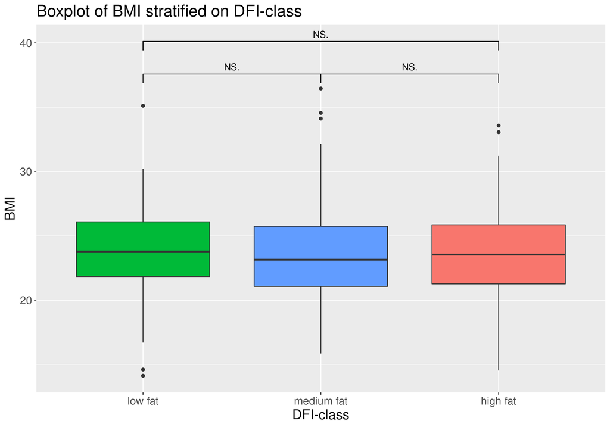

## Some more data exploration

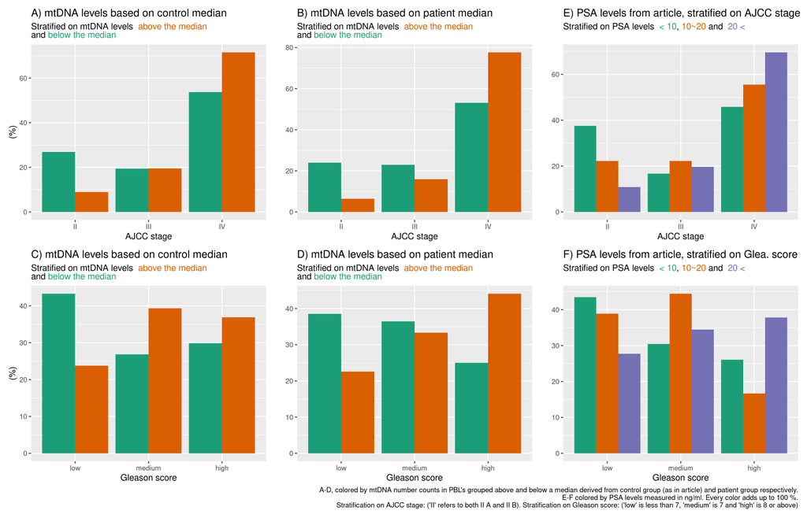

## Conclusion

- We can support the conclusion of the article, mtDNA is a biomarker for prostate cancer (e.g, it is reproducible)
- PSA levels seem to be an even better biomarker
- Both of the above could be supported by logistic regression
- Conclusion for PCA?
- Did we find anything interesting for EDA?